# Projeto travis

```r
library(tidyverse)
library(here)
library(knitr)
theme_set(theme_bw())
```

## Sobre o projeto

Este relatório utiliza dados sobre a utilização de integração continua gerados pelo projeto travis torrent e tem como intenção o estudo do comportamento dos projetos dado as estatísticas geradas. Os dados foram pré-processados pelo professor Nazareno e projeto pode ser acessado aqui: https://github.com/nazareno/travistorrent-eda .

## Lendo os dados

Os dados já processados dos projetos

```r
projetos = read_csv(here::here("data/projetos.csv"))
```

Removendo os dados dos projetos que contém java script.

```r
projetos = projetos %>%
    filter(lang != "javascript")
```

## Buscando respostas

Uma vez que temos os dados derivados dos dados originais podemos fazer algumas análises para ter um entendimento melhor. Com estudo anterior chegou-se a algumas perguntas que podem ser respondidas com os dados. Nesse relatório eu busco responder duas perguntas que são as seguintes:

*Qual linguagem tem uma maior variação de tamanho de projetos?

*Projetos com mais linhas de código são os que tem mais commits?

## Qual linguagem tem uma maior variação de tamanho de projetos?

Para começarmos a entender a variação dos dados primeiramente devemos ver como os tamanhos de projetos estão destribuidos para cada uma das linguagens vendo o tamanho de todos os projetos.

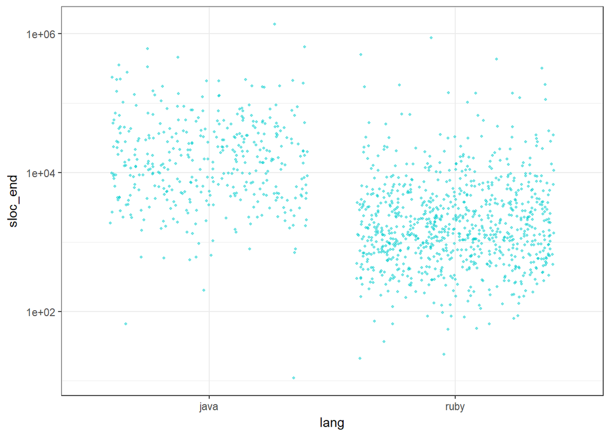

```r
projetos %>%
    ggplot(aes(x = lang,
               y = sloc_end)) +
    geom_jitter(alpha = .5, width = .4, size = .8, color="cyan3") +
    scale_y_log10()
```

Podemos observar a variação no tamanho do projeto porém não podemos afirmar muita coisa com certeza pois as linguagens tem números diferentes de projetos. Uma medida que pode ser utilizada é a diferença entre os pontos máximo e mínimo, porém essa métrica é muito afetada por esses pontos e pode não ser representativo. Para termos uma melhor referência podemos utilizar um boxplot por ser um gráfico mais adequado para a comparação pois o tamanho da caixa do bloxplot não é influenciado pela quantidade de pontos e nem pelos extremos. O tamanho da caixa mostra para a gente a variação dos tamanhos do projeto que é o que queremos chegar a uma conclusão.

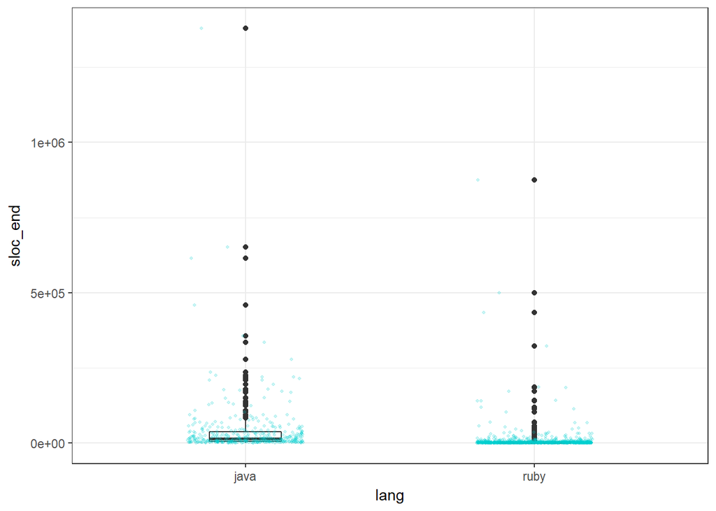

```r
projetos %>%
    ggplot(aes(x= lang,
               y = sloc_end)) +
    geom_boxplot(width = .25)+
    geom_jitter(alpha = .2, width = .2, size = .8, color="cyan3")
```

Para vermos a real diferença entre o tamanho podemos calcular o tamanho da caixa, conhecido por distância interquartil. Para java temos:

```r
 projetos %>%
    filter(lang=="java")%>%
    select(sloc_end)%>%
    unlist()%>%
    as.numeric()%>%
    IQR()
```

```
## [1] 31503
```

Para Ruby temos:

```r
 projetos %>%
    filter(lang=="ruby")%>%
    select(sloc_end)%>%
    unlist()%>%
    as.numeric()%>%
    IQR()
```

```
## [1] 3297
```

A conclusão que podemos chegar é que a diferença de variação em tamanhos de projetos em java e em ruby é consideravel, na minha opinião ruby tem uma variação menor pois seu maior uso é para criação de projetos web que normalmente tem uma estrutura básica parecida. Já a linguagem Java tem projetos que vão desde apenas uma classe até projetos grandes e complexos.

## Outro questionamento

Uma vez respondida essa questão podemos chegar a outro questionamento. Qual a variação do tempo de projeto para cada uma das linguagens?

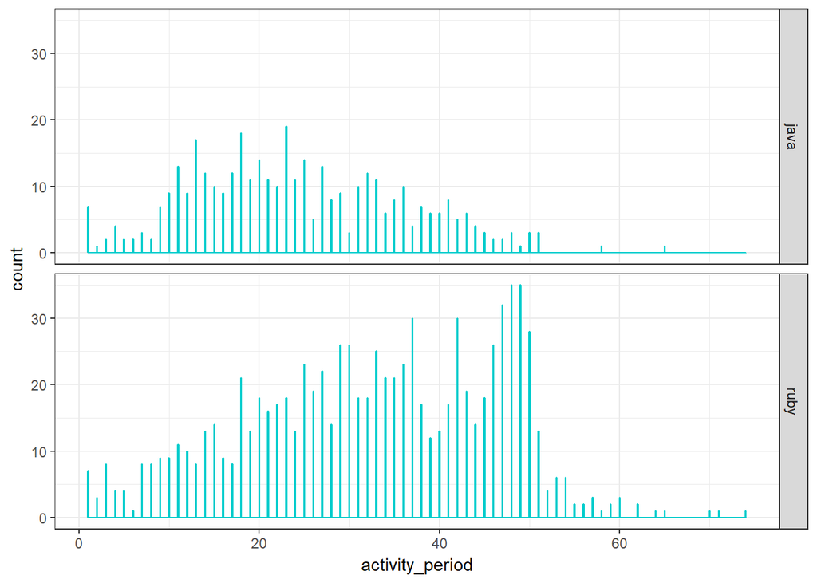

```r
projetos %>%
    ggplot(aes(x = activity_period)) +
    geom_histogram(binwidth = .1, fill="cyan3", color="cyan3")+
    facet_grid(lang ~.)
```

Aparentemente, java tem projetos com menor duração do que ruby. Para vermos a variação assim como no exemplo anterior vamos utilizar o boxplot.

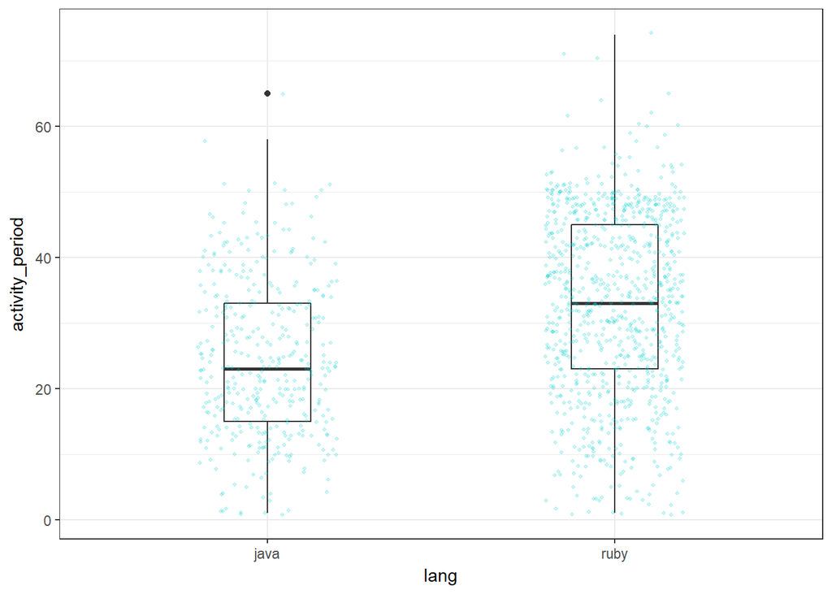

```r
projetos %>%
    ggplot(aes(x= lang,
               y = activity_period)) +
    geom_boxplot(width = .25)+
    geom_jitter(alpha = .2, width = .2, size = .8, color="cyan3")
```

Podemos ver o resultado dessa variação utilizando a distância interquartil. Para java temos:

```r
 projetos %>%
    filter(lang=="java")%>%
    select(activity_period)%>%
    unlist()%>%
    as.numeric()%>%
    IQR()
```

```
## [1] 18
```

Para Ruby temos:

```r
 projetos %>%
    filter(lang=="ruby")%>%
    select(activity_period)%>%
    unlist()%>%
    as.numeric()%>%
    IQR()
```

```
## [1] 22
```

Diferentemente da variação de tamanho de projetos, a diferença entre a variação de tempo de projeto é bem pequena.

## Projetos com mais linhas de código são os que tem mais commits?

Primeiramente vamos gerar um gráfico para ver o comportamento do mesmo.

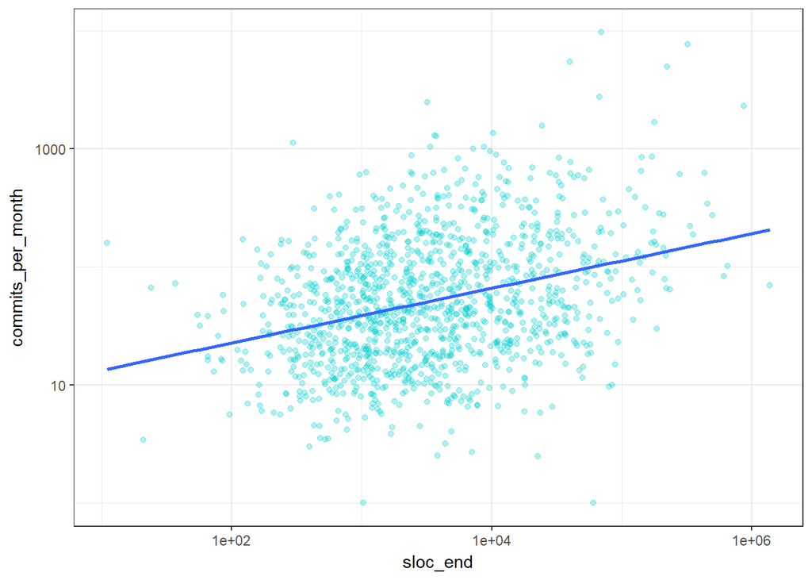

```r
projetos %>%
    ggplot(aes(x = sloc_end,
               y = commits_per_month)) +
    geom_point(alpha = .3, color="cyan3") +
    scale_x_log10() +
    scale_y_log10()+
    geom_smooth(method = "lm", se = FALSE)
```

Aplicando uma escala logarítmica vemos que aparentemente as duas coisas crescem juntas mas para chegarmos a essa conclusão precisaremos utilizar outros métodos para termos essa certeza. A linha azul tem o “best fit” para os dados onde é minimizado o erro da distância entre os pontos e a reta.

```r
projetos %>%
   summarise(correlacao = cor(commits_per_month, sloc_end, method = "pearson"))
```

| correlacao |
| --- |
| 0.2040211 |

## Outro questionamento

Dado que o número de linha não tem uma relação linear com o número de commits, existe alguma relação linear entre o número de commits e o número de programadores no time?

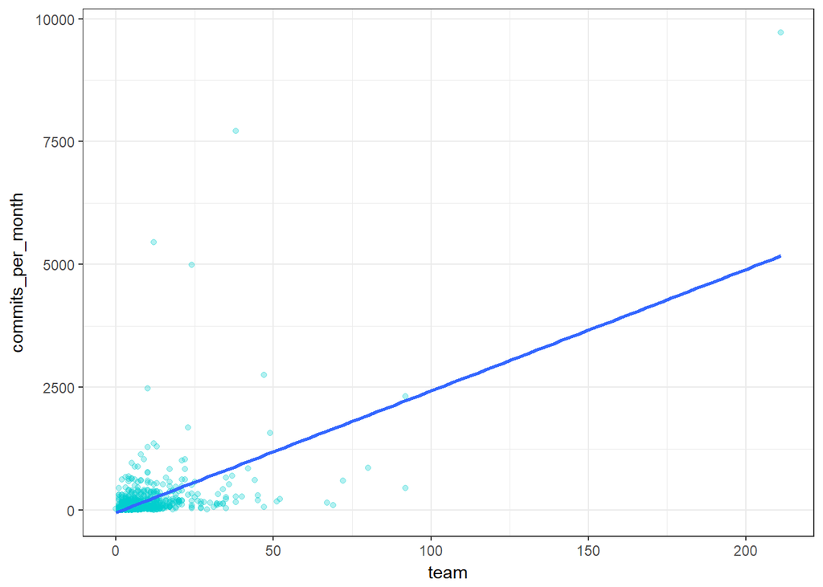

```r
projetos %>%
    ggplot(aes(x = team,
               y = commits_per_month)) +
    geom_point(alpha = .3, color="cyan3") +
    geom_smooth(method = "lm", se = FALSE)
```

Outra vez o gráfico nos mostra que a linha que seria o “best fit” de uma regressão linear é crescente. Vamos verificar se realmente existe essa correlação.

```r
projetos %>%
   summarise(correlacao = cor(commits_per_month, team, method = "pearson"))
```

| correlacao |
| --- |
| 0.5648994 |

O valor de 0,5 indica uma correlação positiva entre as variáveis, no caso crescem juntas, moderada. Isso faz sentido pois quanto mais gente trabalhando num projeto maior deve ser a frequencia de commits para que todos estejam no mesmo nível de entendimento.